# Paleobuddy overview

None of the scenarios we have listed here are specific to speciation or extinction - one can mix and match any combination listed here for either rate.

In the case of sampling rates, it is almost the case that any scenario available to speciation/extinction is available to sampling. We do not allow for a `shape` parameter since the Weibull distribution is not frequently used in the literature for age-dependent sampling. Instead, we allow for the user to supply a probability distribution describing how occurrences are distributed along a species age, as follows

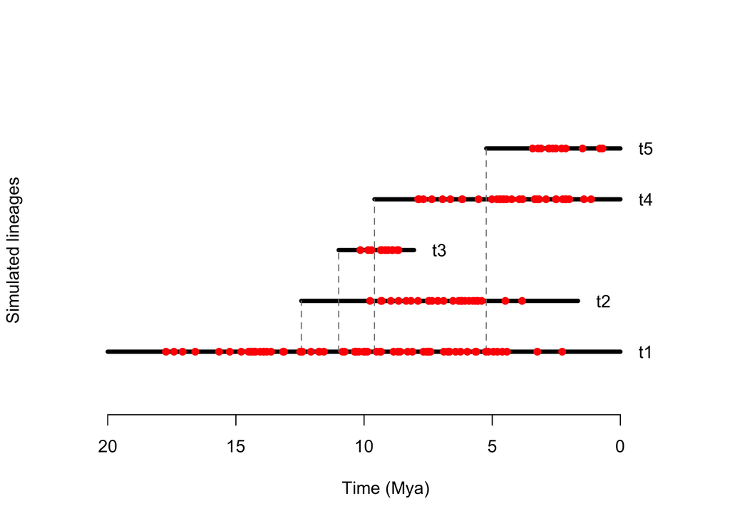

```r
# as an example, we will use a PERT distribution,
# a hat-shaped distribution used in PyRate

# preservation function
dPERT <- function(t, s, e, sp, a = 3, b = 3, log = FALSE) {

  # check if it is a valid PERT
  if (e >= s) {
    message("There is no PERT with e >= s")
    return(rep(NaN, times = length(t)))
  }

  # find the valid and invalid times
  id1 <- which(t <= e | t >= s)
  id2 <- which(!(t <= e | t >= s))
  t <- t[id2]

  # initialize result vector
  res <- vector()

  # if user wants a log function
  if (log) {
    # invalid times get -Inf
    res[id1] <- -Inf

    # valid times calculated with log
    res[id2] <- log(((s - t) ^ 2)*((-e + t) ^ 2)/((s - e) ^ 5*beta(a,b)))
  }

  # otherwise
  else{
    res[id1] <- 0

    res[id2] <- ((s - t) ^ 2)*((-e + t) ^ 2)/((s - e) ^ 5*beta(a,b))
  }

  return(res)
}

# set seed
set.seed(1)

# generate a quick simulation
sim <- bd.sim(n0, lambda = 0.1, mu = 0.05, tMax = 20)

# sample for the first 10 species
fossils <- suppressMessages(sample.clade(sim = sim, rho = 3,
                                      tMax = 20, adFun = dPERT))
# here we return true times of fossil occurrences

# draw longevities with fossil occurrences
draw.sim(sim, fossils = fossils)
```

Note how occurrences cluster in the middle of a species’ duration, as expected since the PERT is a hat-shaped distribution.

For more details and examples of age-dependent models, check out `?sample.clade`. Even if an `adFun` argument is supplied for age dependency, the average sampling rate `rho` may have the same flexibility as speciation and extinction rates in the birth-death functions.

We provide below a final example containing a lot of complexity on both birth-death and fossil sampling rates. While set not to run due to its long runtime, users are encouraged to run it on their own time, and use it as a basis for the exploration of other sources of variation for rates (e.g. try using the PERT to make fossil sampling age-dependent, as above). It is completely self-contained, as long as paleobuddy is attached.

```r
## setup
# set seed
set.seed(123)

# initial number of species
n0 <- 1

# number of extant species
tMax <- 10

# lambda varies with absolute time (exponential decay)
lambda <- function(t) {
  1 + exp(-t/2)
}

# mu will vary with species age and environmental variables
data(co2)
data(temp)

# its scale will depend on CO2, except for a mass extinction event
scale <- function(t, env) {
  ifelse(t < 10, env/20,
         ifelse(t < 11, 1/1.9, env/30))
  # ME between 10 and 11my from simulation start
  # step function-like dependence on CO2 otherwise
}
mu <- make.rate(scale, tMax = tMax, envRate = co2)

# its shape will vary with time and temperature
shape <- function(t, env) {
  0.5 + 2.5 * log(t + 1) / env
}
mu_shape <- make.rate(shape, tMax = tMax, envRate = temp)

# finally, fossil sampling will vary linearly with absolute time
rho <- function(t) {
  0.1 + 0.1 * t
}

## plot diversification rates to visualize
# time vector
time <- seq(0, tMax, by = 0.01)

# plotting lambda, mu scale, and mu shape
plot(time, rev(lambda(time)), type = "l", xlim = c(tMax, 0), ylim = c(0, 2),
     xlab = "Time (Mya)", ylab = "Rate value",
     main = "Speciation rate, extinction scale and shape through time",
     col = "orange")
lines(time, rev(1/mu(time)), col = "red")
lines(time, rev(mu_shape(time)), col = "blue")
legend(x = 15, y = 0.7, lty = 1, col = c("orange", "red", "blue"),
       legend = c("lambda", "1/(mu scale)", "mu shape"))
# note we plotted the inverse of scale, since Weibull scales are
# equivalent to exponential rates when shape is equal to 1

## simulate
# birth-death simulation
sim <- suppressMessages(bd.sim(n0, lambda, mu, tMax, mShape = mu_shape))

# fossil record simulation - returning true sampling times
fossils <- suppressMessages(sample.clade(sim, rho, tMax, returnTrue = TRUE))

# draw BD simulation with fossils
draw.sim(sim, fossils = fossils, showLabel = FALSE)

# draw phylogenetic tree
ape::plot.phylo(make.phylo(sim), show.tip.label = FALSE)
```

## State-dependent speciation, extinction, and fossil sampling

Starting with version 1.1, paleobuddy now also allows for trait-dependent diversification models, both for birth-death and fossil sampling simulations, through use of the `bd.sim.traits` and `sample.clade.traits` functions. To illustrate these features, we’ll run a simple workflow simulating the Binary state-dependent speciation and extinction (BiSSE) model (Maddison et al 2007, see `?bd.sim.traits` for full reference).

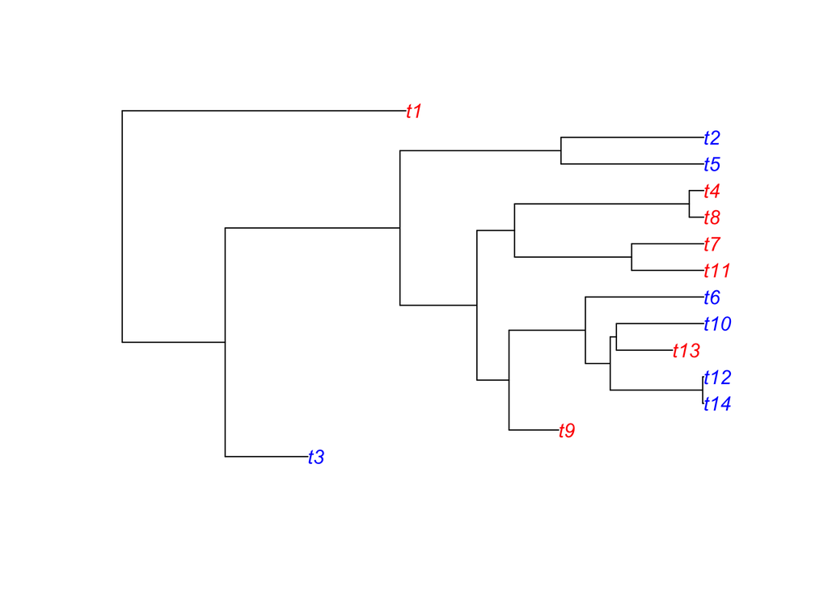

```r
# set seed
set.seed(1)

# initial number of species
n0 <- 1

# number of extant species at the end of the simulation
N <- 10
# conditioning the simulation on the number of extant species
# is also a new feature of version 1.1!

# speciation, higher for state 1
lambda <- c(0.1, 0.2)

# extinction, higher for state 0
mu <- c(0.06, 0.03)

# number of traits and states for each--one binary trait
nTraits <- 1
nStates <- 2

# initial value of the trait
X0 <- 0

# trait transition matrix--it's a list
# to allow for the case with multiple traits
Q <- list(matrix(c(0, 0.1, 0.1, 0), nrow = 2, ncol = 2))

# run simulation
sim <- bd.sim.traits(n0, lambda, mu, N = N, nTraits = nTraits,
                     nStates = nStates, X0 = X0, Q = Q)

# extract sim object and trait data frames
traits <- sim$TRAITS
sim <- sim$SIM

# make phylogeny
phy <- make.phylo(sim)

# get trait values for all tips, using the new traits.summary function
tip_traits <- traits.summary(sim, traits)$trait1

# plot phylogenetic tree coloring for the trait
ape::plot.phylo(phy, tip.color = c("red", "blue")[tip_traits + 1])
```

We can also have fossil sampling be trait-dependent, of course.

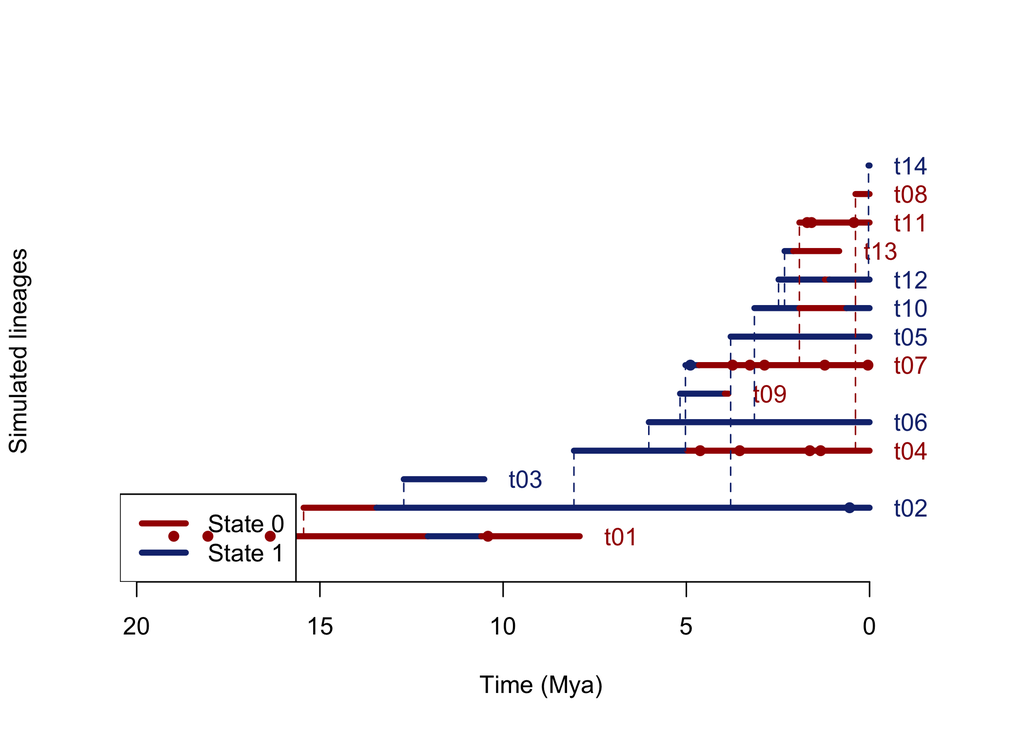

```r
# set seed
set.seed(1)

# fossil sampling rate, higher for state 0
rho <- c(0.5, 0.1)

# run fossil sampling
fossils <- sample.clade.traits(sim, rho, max(sim$TS),
                               traits, nStates = nStates)

# extract fossil record (fossils$TRAITS would be the same as sim$TRAITS here)
fossils <- fossils$FOSSILS

# extract trait values for both fossils and extant species
tip_traits <- traits.summary(sim, traits, fossils,
                             selection = "sampled")$trait1

# we can visualize the simulation and fossils using draw.sim
draw.sim(sim, traits, fossils, traitLegendPlacement = "bottomleft")
```

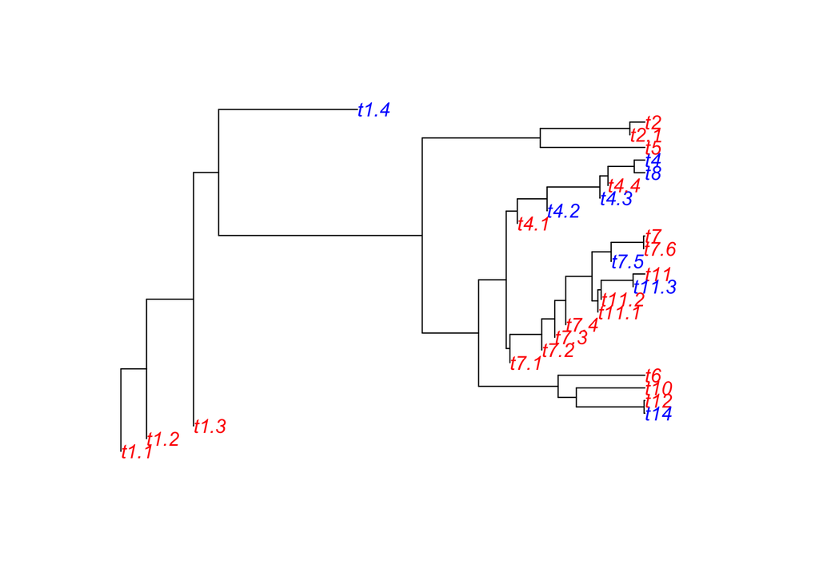

```r
# we can get a phylogeny including extant species and fossils, to
# simulate a reconstructed phylogeny used in fossilized birth-death models
phy <- make.phylo(sim, fossils, returnTrueExt = FALSE)
# returnTrueExt being false means the tips representing the true extinction
# will be dropped, and the last sampled fossil will be in its place

# plot phylogenetic tree coloring for the trait
ape::plot.phylo(phy, tip.color = c("red", "blue")[tip_traits + 1])
```

```r
# here sampled ancestor fossils are represented as 0-length branches,
# so that the tree could be used e.g. for a Beast2 analyses
# some software prefer a degree-2 node, in which case one could set the
# saFormat parameter of make.phylo to "node"
```

There are a multitude of ways to complicate these simulations. We could, e.g., allow for more states per trait, or more traits, where some traits might evolve neutrally with regards to diversification, and/or speciation and extinction depend on different traits. We could also allow for hidden traits to control diversification, to test the hidden state-dependent speciation and extinction model (HiSSE; Beaulieu & O’Meara 2016, see `?bd.sim.traits` for full reference) and its extensions. Fossil sampling has similar flexibility, with the exception of allowing for more traits since there is only one rate in that model. See `?bd.sim.traits` and `?sample.clade.traits` for examples exploring all the flexibility of these functions. Furthermore, see `?make.phylo` and `draw.sim` to check out the new features of these functions.

## Conclusion

For completion, we present a final list of the functions of the package

- `bd.sim` birth-death simulator. Rates can be constant, time dependent, time and environmentally dependent, or a list of numbers. User can supply a shape parameter to make rate a Weibull scale. With the release of version 1.1, both `bd.sim` and the new `bd.sim.traits` (see below) allow for conditioning the simulation on either the maximum simulation time (`tMax`, as was originally implemented) or the number of extant species at the end of the simulation (`N`, see `?bd.sim` for implementation details).
- `bd.sim.traits` functions like `bd.sim`, but for trait-dependent diversification rates. There is no limit to the number of traits (though speciation and extinction can only depend on one of those each), the number of states per trait (observed or hidden), or the parameters of trait evolution. In terms of models currently in the literature, `bd.sim.traits` can model BiSSE (Maddison et al 2007), MuSSE (Fitzjohn 2012), and HiSSE (Beaulieu & O’Meara 2016, see `?bd.sim.traits` for full references).
- `make.phylo` creates a `phylo` object from the `ape` package. With the release of version 1.1, it now allows for the inclusion of fossil samples on the phylogeny as either 0-length branches or degree-2 nodes for use with fossilized birth-death models (Heath et al 2014, see `?make.phylo` for full reference).
- `sample.clade` simulates fossil samples from a set of species, usually outputted from `bd.sim`. Sampling rate can be anything a speciation or extinction rate can be, without the option of a shape parameter. The user may instead supply a distribution of occurrences across a species age, so as to simulate age-dependency in sampling with more flexibility.
- `sample.clade.traits` is to `sample.clade` what `bd.sim.traits` is to `bd.sim`, i.e. trait-dependent fossil sampling. It can simulate all models `bd.sim.traits` can, though the fact that there is only one rate leads to some caveats (see `?sample.clade.traits`).
- `draw.sim` function to draw longevities of the species in a `sim` object and, optionally, fossil occurrences of these species. With the release of version 1.1, it now allows for the coloring of edges and fossil samples with regards to trait values.
- `rexp.var` exponential and Weibull waiting time drawing with variable rates. Used by `bd.sim` and `sample.clade`.
- `find.lineages` separates a group returned by the `bd.sim` function, or similar, by the species that started the simulation as mothers of each group. Allows for an optional argument, a list of numbers, and if supplied returns the groups generated by those species instead. A quick example:

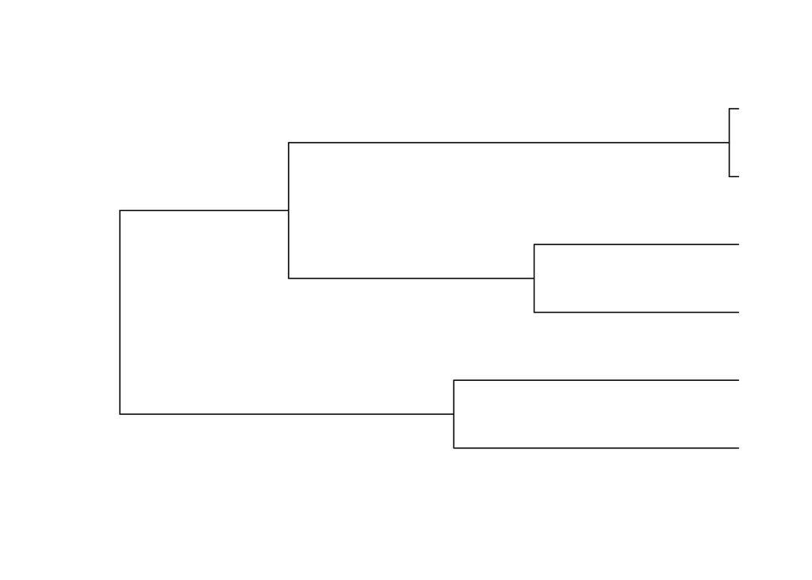

```r
# set a seed
set.seed(1)

# simple simulation, starting with more than one species
sim <- bd.sim(n0 = 2, lambda = 0.1, mu = 0, tMax = 20, nFinal = c(20, Inf))

# separate the lineages
clades <- find.lineages(sim)

# plot each phylogeny

# clade 1
ape::plot.phylo(make.phylo(clades$clade_1$sim), show.tip.label = FALSE)
```

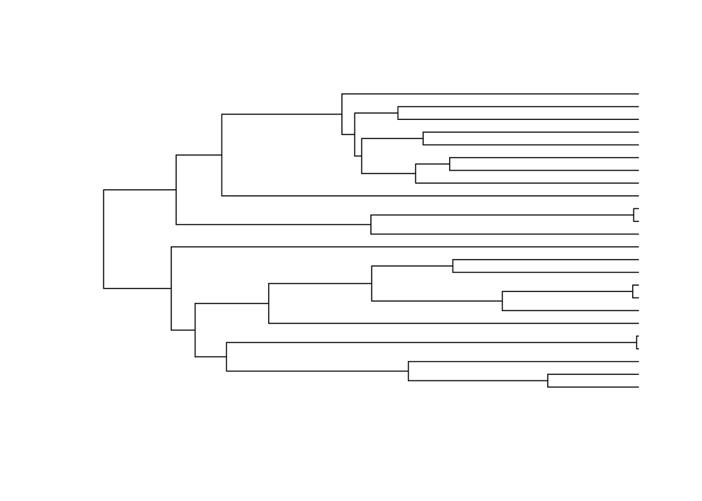

```r
# clade 2
ape::plot.phylo(make.phylo(clades$clade_2$sim), show.tip.label = FALSE)
```

- `phylo.to.sim` creates a `sim` object from a phylogeny following the APE `phylo` class format (Paradis et al 2004). Can be used to integrate paleobuddy with other packages that output phylogenies. Note that the user must supply some optional arguments to allow for this; most importantly the information of each species’ mother, since this is ambiguous from a bifurcating phylogeny.
- `make.rate` creates a function of time from the customization options presented above - vector of numbers and vector of shift times, function of time and environment and an environment matrix, etc. Used by `bd.sim` and `sample.clade` to detect when the given rates are constant, and create the rates to pass to the helper functions.
- `traits.summary` creates vectors listing the trait values of each species in a simulation (usually the output of `bd.sim.traits`), with flexibility on the range of species included, in particular with the inclusion of fossil species as well. These vectors can then easily be saved as Nexus data files.
- `var.rate.div` calculates the expected diversity from a variable rate birth-death process and a time period.
- `binner` given occurrence times and time bins, returns the number of occurrences in each bin.
- Finally, there are a number of generics and methods for the `sim` class, like `print.sim` and `plot.sim`. See `?sim` for a detailed list.

While there are a number of areas where `paleobuddy` can improve, it is clear that the package presents unprecedented flexibility on diversification, fossil record, and phylogeny generation. It will therefore be an impactful tool in the exploration of complex evolutionary scenarios.